# Lab 9

Support Vector Machines  
*Textbook: An Introduction to Statistical Learning with Applications in R*

```r
# clear the workspace
rm(list=ls())
```

## Support Vector Classifier

The `svm()` function (library `e1071`) can be used with setting a hyperparameter `cost`.

> larger cost: narrower margin, less mislabelled training data, higher variance

> smaller cost: wider margin, more mislabelled training data, lower variance

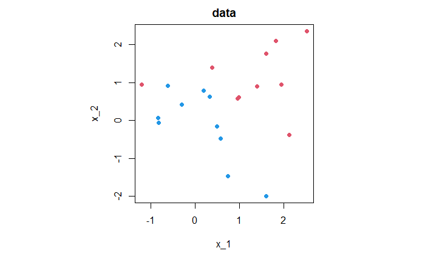

```r
library(e1071)
# create 40 observations of data, with 2-dim feature space
set.seed(1)
x = matrix(rnorm(20*2), ncol=2)
y = c(rep(-1, times=10), rep(1, times=10))
# increase predictors by 1 if y == 1
x[y==1,] = x[y==1,] + 1
# plot data
par(pty="s") # axis square
plot(x, pch=19, col=3-y, main="data", xlab="x_1", ylab="x_2")
```

The data is not separable. We use svm (linear kernel, cost = 10) to fit the data.

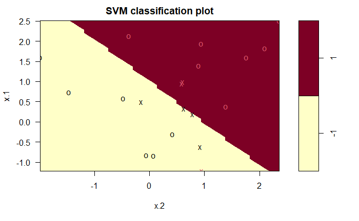

```r
# create dataframe
df = data.frame(x=x, y=as.factor(y))
# svm (linear kernel, cost = 10)
svm_linear = svm(y~., data=df, kernel="linear", cost=10, scale=FALSE)
# plot
plot(svm_linear, df)
```

```r
# print the summary
summary(svm_linear)
```

```
Call:
svm(formula = y ~ ., data = df, kernel = "linear", cost = 10, scale = FALSE)


Parameters:
   SVM-Type:  C-classification
 SVM-Kernel:  linear
       cost:  10

Number of Support Vectors:  7

 ( 4 3 )


Number of Classes:  2

Levels:
 -1 1
```

```r
names(svm_linear)
```

```
 [1] "call"            "type"            "kernel"          "cost"            "degree"
 [6] "gamma"           "coef0"           "nu"              "epsilon"         "sparse"
[11] "scaled"          "x.scale"         "y.scale"         "nclasses"        "levels"
[16] "tot.nSV"         "nSV"             "labels"          "SV"              "index"
[21] "rho"             "compprob"        "probA"           "probB"           "sigma"
[26] "coefs"           "na.action"       "fitted"          "decision.values" "terms"
```

The `index` attribute of the svm model gives the **index of the support vectors**.

```r
# print out the index of the support vectors
svm_linear$index
```

```
[1]  1  2  5  7 14 16 17
```

## Hyperparameter Tuning

The `tune()` function (`e1071` library) can be used to tune the hyperparameters in a model by 10-fold cross-validation.

```r
# tune different cost values
model_tuning = tune(svm, y~., data=df, kernel="linear",
                    range=list(cost=c(0.001, 0.01, 0.1, 1, 2, 5, 10, 100, 1000)))
# print summary
summary(model_tuning)
```

```
Parameter tuning of ‘svm’:

- sampling method: 10-fold cross validation

- best parameters:
```

|  | cost |
| --- | --- |
|  | 5 |

```
- best performance: 0.1

- Detailed performance results:
```

| cost | error | dispersion |
| --- | --- | --- |
| 1e-03 | 0.65 | 0.4743416 |
| 1e-02 | 0.65 | 0.4743416 |
| 1e-01 | 0.15 | 0.3374743 |
| 1e+00 | 0.15 | 0.2415229 |
| 2e+00 | 0.15 | 0.2415229 |
| 5e+00 | 0.10 | 0.2108185 |
| 1e+01 | 0.10 | 0.2108185 |
| 1e+02 | 0.15 | 0.2415229 |
| 1e+03 | 0.15 | 0.2415229 |

```
NA
```

```r
# inspect tuning outputs
names(model_tuning)
```

```
[1] "best.parameters"  "best.performance" "method"           "nparcomb"         "train.ind"
[6] "sampling"         "performances"     "best.model"
```

We can see the best parameters using the `$best.parameters` attribute. We can call `$best.model` to return the best model.

```r
# best hyperparameters
model_tuning$best.parameters
```

|  | cost |
| --- | --- |
| 6 | 5 |

```r
# print details of the best model
summary(model_tuning$best.model)
```

```
Call:
best.tune(method = svm, train.x = y ~ ., data = df, ranges = list(cost = c(0.001, 0.01,
    0.1, 1, 2, 5, 10, 100, 1000)), kernel = "linear")


Parameters:
   SVM-Type:  C-classification
 SVM-Kernel:  linear
       cost:  5

Number of Support Vectors:  8

 ( 4 4 )


Number of Classes:  2

Levels:
 -1 1
```

Use `predict()` to test on the test data.

```r
# create test data
X_test = matrix(rnorm(20*2), ncol=2) # shape = (20, 2)
y_test = sample(c(-1, 1), size=20, replace=TRUE)
X_test[y_test==1, ] = X_test[y_test==1, ] + 1
# create test dataframe
df_test = data.frame(x=X_test, y=as.factor(y_test))
# predict
pred = predict(model_tuning$best.model, df_test)
# confusion matrix
table(real=y_test, predict=pred)
```

```
    predict
real -1  1
  -1 10  1
  1   2  7
```

The svm misclassified 3 out of 20 test observations.

## Support Vector Machine

**Non-linear kernels**

`svm(..., kernel = radial, gamma = 1, cost = 1)` fits SVM with radial kernels (with hyperparameter gamma)

Setting `kernel = polynomial` uses the polynomial kernels.

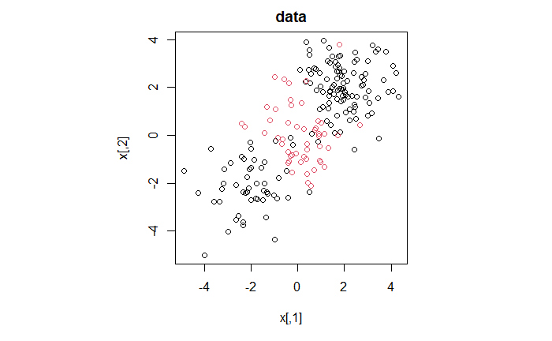

```r
# generate data
x = matrix(rnorm(200*2), ncol=2) # shape = ()
x[1:100,] = x[1:100,] + 2
x[101:150,] = x[101:150,] - 2
y = c(rep(1, 150), rep(2, 50))
par(pty="s") # axis square
plot(x, col=y, main="data")
```

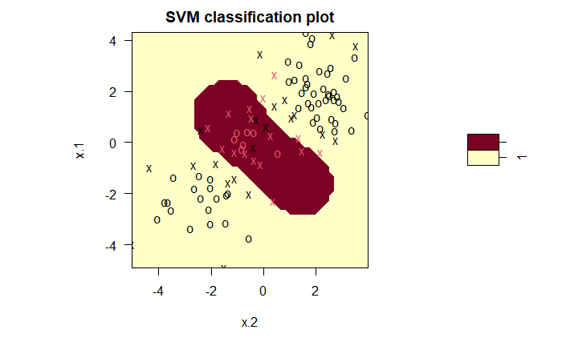

```r
# create dataframe
df = data.frame(x=x, y=as.factor(y))
# split into training (n=100) and test (n=100) sets
train_index = sample(200, 100)
# svm fitting (radial kernel)
svm_radial = svm(y~., data=df[train_index,], kernel="radial", gamma=1, cost=1)
# see fitting result
plot(svm_radial, df[train_index,])
```

Similarly, we can use the `tune()` function to find the best combination of `gamma` and `cost`.

```r
# tuning the hyperparamenters 'cost' and `gamma`
tuning_models = tune(svm, y~., data=df, kernel="radial",
                     ranges=list(cost=c(0.01, 0.1, 1, 2, 10, 100, 1000),
                                 gamma=c(0.1, 0.5, 1, 2, 3, 4, 5, 10)))
```

Inspect the best hyperparameters and the performance

```r
tuning_models$best.parameters
```

|  | cost | gamma |
| --- | --- | --- |
| 38 | 1 | 4 |

```r
summary(tuning_models$best.model)
```

```
Call:
best.tune(method = svm, train.x = y ~ ., data = df, ranges = list(cost = c(0.01, 0.1, 1,
    2, 10, 100, 1000), gamma = c(0.1, 0.5, 1, 2, 3, 4, 5, 10)), kernel = "radial")


Parameters:
   SVM-Type:  C-classification
 SVM-Kernel:  radial
       cost:  1

Number of Support Vectors:  78

 ( 48 30 )


Number of Classes:  2

Levels:
 1 2
```

```r
# predict on test data
pred = predict(tuning_models$best.model, x[-train_index,])
# confusion matrix
table(real = y[-train_index], pred = pred)
```

```
    pred
real  1  2
   1 70  3
   2  2 25
```

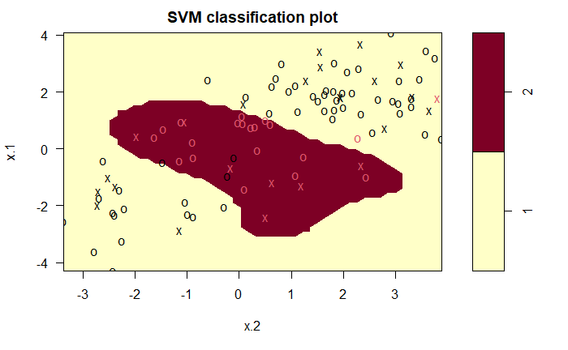

```r
# plot
plot(tuning_models$best.model, df[-train_index, ])
```

## ROC Curves

```r
library(ROCR)
```

The `performance(prediction.obj, measure, x_measure)` function (`ROCR` library) calculates the specified metrics.

We set `measure = "tpr"` and `x_measure = "fpr"` to return **true positive rate** and **false positive rate**.

ROCR routine starts with creating a **prediction object** by calling the function `prediction(predictions, labels)`.

```r
# helper function to plot the ROC curve
plot_ROC = function(pred_values, real_labels, ...){

  # pred_values: predicted values
  # real_labels: real labels

  pred_obj = prediction(pred_values, real_labels, label.ordering = c(2, 1))

  # performance metrics tpr and fpr
  tpr_fpr = performance(pred_obj, "tpr", "fpr")

  # plot ROC
  plot(tpr_fpr, ...)
}
```

`svm(..., decision.values=TRUE)` outputs the fitted value instead of the predicted class.

```r
svm_radial_values = svm(y~., data=df[train_index,], kernel="radial", gamma=0.5, cost=10, decision.values=TRUE)
# predict on training data
pred_values_train = attributes(predict(svm_radial_values, df[train_index,], decision.values=TRUE))$decision.values
# plot ROC
par(pty="s") # axis square
plot_ROC(pred_values_train, df[train_index,"y"], main="ROC", col="blue", lwd=2)
# predict on test data
pred_values_test = attributes(predict(svm_radial_values, df[-train_index,], decision.values=TRUE))$decision.values
# plot ROC
plot_ROC(pred_values_test, df[-train_index,"y"], col="red", add=TRUE, lwd=2)
```

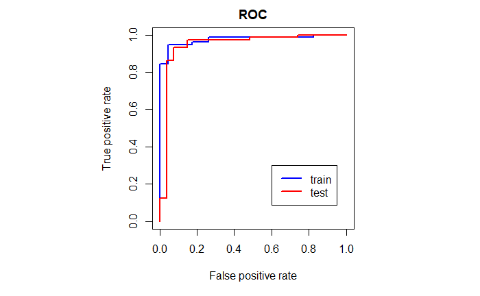

```r
# add legend
legend(0.6, 0.3, legend=c("train", "test"), col=c("blue", "red"), lty=c(1,1), lwd=2)
```

## Application to Gene Expression Data

```r
library(ISLR)
# the Khan dataset
names(Khan)
```

```
[1] "xtrain" "xtest"  "ytrain" "ytest"
```

```r
attach(Khan)
```

```r
# shape of the data
dim(xtrain)
```

```
[1]   63 2308
```

```r
dim(xtest)
```

```
[1]   20 2308
```

The training size is 63 and the test size is 20. Each data has a 2308-dimensional features.

Use a **linear kernel** because the dimension of the features is much greater than the number of observations. Using polynomial of radial kernels will result in greater feature size.

We use the `tune()` function to find the best value of `cost`.

```r
# create the dataframe
df = data.frame(x = xtrain, y = as.factor(ytrain))
# use cross validation to test different cost values
candidates = tune(svm, y~., data=df, kernel="linear", ranges=list(cost=c(0.01, 0.1, 1, 5, 10, 20, 100, 1000)))
# the best cost
print(candidates$best.parameters)
```

|  | cost |
| --- | --- |
| 1 | 0.01 |

```r
summary(candidates)
```

```
Parameter tuning of ‘svm’:

- sampling method: 10-fold cross validation

- best parameters:
```

|  | cost |
| --- | --- |
|  | 0.01 |

```
- best performance: 0.01428571

- Detailed performance results:
```

| cost | error | dispersion |
| --- | --- | --- |
| 1e-02 | 0.01428571 | 0.0451754 |
| 1e-01 | 0.01428571 | 0.0451754 |
| 1e+00 | 0.01428571 | 0.0451754 |
| 5e+00 | 0.01428571 | 0.0451754 |
| 1e+01 | 0.01428571 | 0.0451754 |
| 2e+01 | 0.01428571 | 0.0451754 |
| 1e+02 | 0.01428571 | 0.0451754 |
| 1e+03 | 0.01428571 | 0.0451754 |

```
NA
```

It seems that all cost values gives the same performance.

```r
# predict on the test data
pred = predict(candidates$best.model, xtest)
# confusion matrix
table(truth = ytest, prediction = pred)
```

```
     prediction
truth 1 2 3 4
    1 3 0 0 0
    2 0 6 0 0
    3 0 2 4 0
    4 0 0 0 5
```

Among the 20 test data, 2 of them are misclassified (actual class 3, predicted as class 2).